# Explore weather trends

## Exploring Weather Trends

The objective of this paper is to analyse the local (Montreal in my case) and the global temperature data and compare the temperature trends.

```python
# Import all the packages needed for my analysis
import pandas as pd
import matplotlib.pyplot as plt
%matplotlib inline
```

```python
# Load data
df=pd.read_csv(r'C:/Users/HP/Documents/UDACITY/PROJECT1/results.csv', index_col='year')

#print first five rows of the dataset
df.head()
```

| year | local temp | global temp |
| --- | --- | --- |
| 1750 | 5.00 | 8.72 |
| 1751 | 5.62 | 7.98 |
| 1752 | -3.22 | 5.78 |
| 1753 | 4.44 | 8.39 |
| 1754 | 4.54 | 8.47 |

```python
#print Last two rows of the dataset
df.tail(2)
```

| year | local temp | global temp |
| --- | --- | --- |
| 2012 | 7.09 | 9.51 |
| 2013 | 7.86 | 9.61 |

```python
# View dimensions of dataset-Number of rows and columns
df.shape
```

```
(264, 2)
```

> **This weather dataset provides information about the temperature for the world as well as for Montreal, between 1750 and 2013.**

```python
#  A concise summary of the dataframe,including the number of non-null values in each column
df.info()
```

```
<class 'pandas.core.frame.DataFrame'>
Int64Index: 264 entries, 1750 to 2013
Data columns (total 2 columns):
 #   Column       Non-Null Count  Dtype
---  ------       --------------  -----
 0   local temp   264 non-null    float64
 1   global temp  264 non-null    float64
dtypes: float64(2)
memory usage: 6.2 KB
```

```python
#count total rows in each column which contain null values
df.isnull().sum()
```

```
local temp     0
global temp    0
dtype: int64
```

```python
#count total rows in each column which contain null values
df.isin([0]).sum()
```

```
local temp     0
global temp    0
dtype: int64
```

```python
# print descriptive statistics for each column of data
df.describe()
```

|  | local temp | global temp |
| --- | --- | --- |
| count | 264.000000 | 264.000000 |
| mean | 4.440455 | 8.359394 |
| std | 1.069468 | 0.575184 |
| min | -3.220000 | 5.780000 |
| 25% | 3.860000 | 8.077500 |
| 50% | 4.420000 | 8.365000 |
| 75% | 5.040000 | 8.700000 |
| max | 7.860000 | 9.730000 |

> **Overall, it appears that Montreal is cooler on average compared to the global average. Indeed, the average temperature in Montreal, between 1750 and 2013, was 4.44 °C compared to 8.36 °C for the global average temperature.**

```python
#correlation between the two variables
df[['local temp','global temp']].corr()
```

|  | local temp | global temp |
| --- | --- | --- |
| local temp | 1.000000 | 0.721534 |
| global temp | 0.721534 | 1.000000 |

> **The temperature data in Montreal and in the world are highly and positively correlated, with a correlation coefficient of 0.72 and have the same trend (see figure below) .**

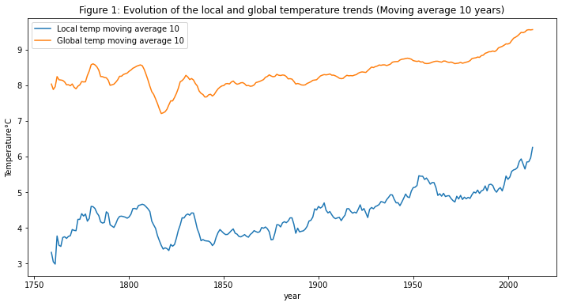

```python
#calculate 10 years moving average and plot
df['Global temp moving average 10']=df['global temp'].rolling(window=10).mean()
df['Local temp moving average 10']=df['local temp'].rolling(window=10).mean()

#plot the two calculated moving average
df['Local temp moving average 10'].plot(figsize=(12,6))
df['Global temp moving average 10'].plot(figsize=(12,6))
plt.title("Figure 1: Evolution of the local and global temperature trends (Moving average 10 years)")
plt.ylabel('Temperature°C')
plt.legend();
```

> **An upward trend has been observed both in Montreal and globally, and has intensified in recent years, most notably in Montreal with a temperature peak of 7.86 °C in 2013 compared to an average of 5.01 °C between 1900 and 2013, and the global temperature increased to 9.61 °C in 2013 compared to an average of 8.75 °C between 1900 and 2013.**

## Conclusion

As a conclusion the world is getting hotter, and the rate of warming in Montreal is going faster. Indeed, the temperature in Montreal has risen by 3.20 °C between 1900 and 2013, about triple the global rate (increase of 1.11°C over this same period).